# Analysing Spatial Data for Biodiversity Conservation

Jonáš Gaigr

Nature Conservation Agency of the Czech Republic  
Department of Biodiversity Monitoring  
Handout: spatial-analysis.pdf

TAIEX Expert Mission on GIS and biodiversity data management | Pristina

## What this session covers

- **The data reality** – what Kosovo’s published record shows, and why a thin baseline is no reason to wait.
- **Earth observation** – land-cover change and habitat fragmentation from Copernicus, and a species model built on them, available today at no cost.
- **One system, shared standards** – from project hard drives to a central biodiversity information system built on Darwin Core and INSPIRE.
- **Three working models** – Czech tiered open data, a Ukrainian GBIF viewer for impact assessment, English district level licensing.
- **Next steps** – what makes Kosovo’s nature data fundable.

## No baseline is not a reason to wait

Permits, road alignments and quarry extensions are decided this week, with or without a map. Data does not add a decision – it makes the one being taken checkable.

## Kosovo’s published record: thin, and concentrated

- **46,831** GBIF records – about **four per km²**.
- **28 %** of them come from **one wetland of 1.1 km²**.
- **48** protected sites have a boundary; **28** of those hold **no record**.
- **189** sites exist only as **a point** – nothing to intersect, report on or defend.

*Published* is not *known*: theses and survey reports hold far more, unseen.

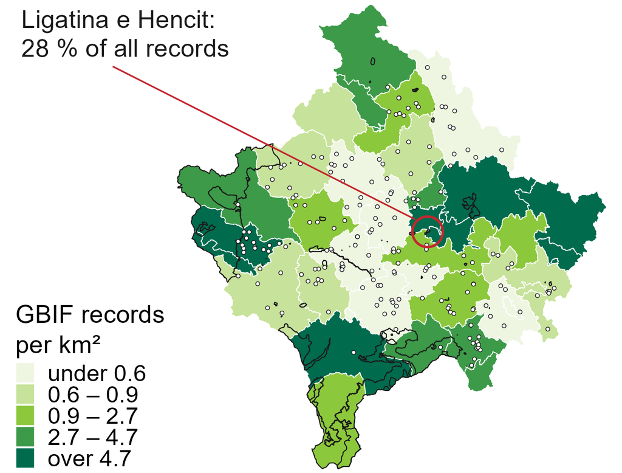

Records per km² by municipality. Outlined: the 48 sites with a boundary. Circles: the 189 point-only sites. GBIF extract behind this repository’s report; sites from the EEA register, v24, July 2026.

## A missing baseline is not a reason for inaction

**Decisions are taken anyway**

Every impact assessment and permit already answers the biodiversity question – from data, or from a site visit somebody remembers.

The choice is between an answer that can be checked and one that cannot.

**“No record” is not “no species”**

Under the Habitats Directive the burden sits with the project: it must show, beyond reasonable scientific doubt, that a site will not be harmed.

A blank map is a risk to the developer and to the ministry – not a clean bill of health.

**The past can still be observed**

Nobody can survey 2016 again. The satellites already did – at 10 m, every few days, since 2015.

The Earth-observation archive is the one baseline that can still be collected **retrospectively**.

Start with the evidence that already exists for the whole territory and costs nothing.

## Land-cover change from Copernicus

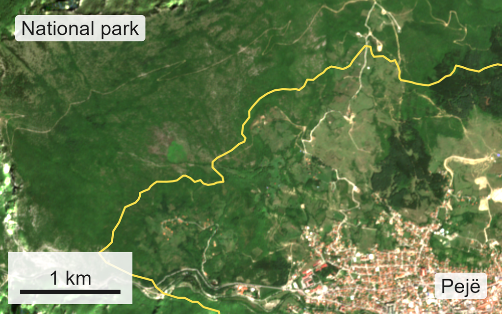

Sentinel-2, 15 August 2016. Bjeshkët e Nemuna National Park (yellow line) above Pejë.

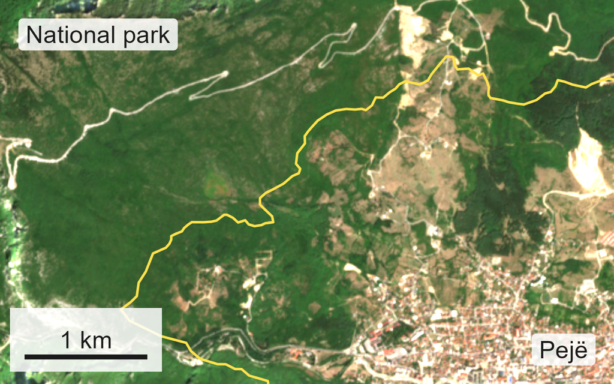

The same 5 km, 10 August 2025: a new road through the forest, inside the park.

**Sentinel-2** – 10 m, free, archive from 2015. **CORINE Land Cover** – harmonised classes and change layers for 39 European countries, Kosovo included. Together: *where* land cover changed, *how much*, and *when*.

## Fragmentation: connection, not just cover

- **Patch size and isolation** – how much habitat, in how many pieces, how far apart.
- **Effective mesh size** – the chance that two random points are still connected; the EEA’s fragmentation measure.
- **Barriers** – motorways, fenced corridors, reservoirs, from the road and water network.

**What it cannot see:** species, habitat condition, anything under a canopy or in a cave. It tells field teams **where** to go – it does not replace them.

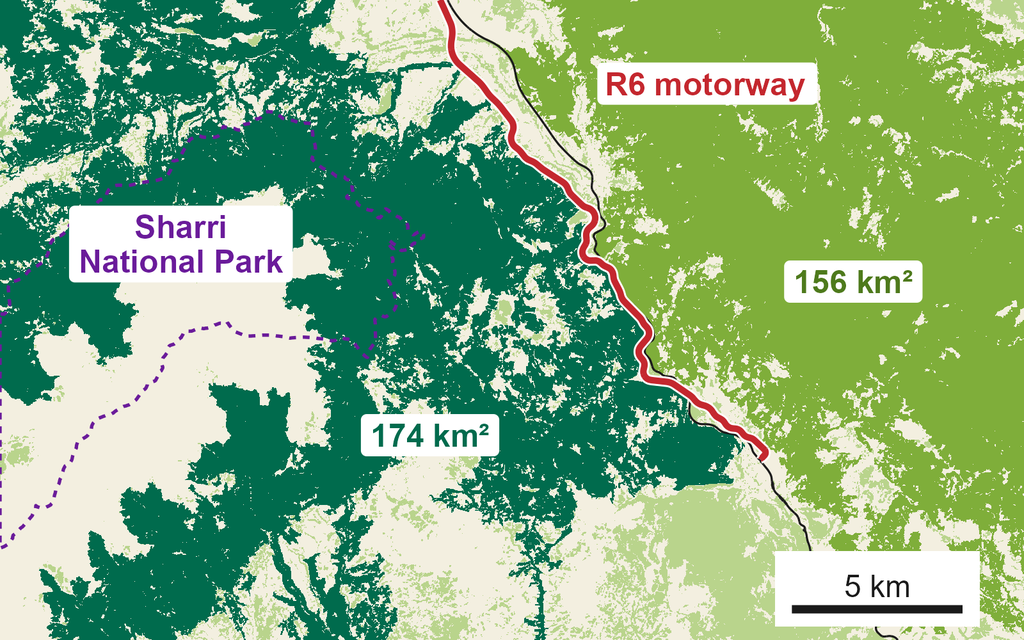

Forest, CLC+ Backbone 2021 (10 m), Kaçanik gorge. Each dark tone is one connected patch; pale, over 9,000 smaller ones. Black: the old main road.

## Species distribution model: the Eros blue

1. **Existing occurrence.** Kosovo: 25 records in nine 10 km atlas squares, one confirmed since 2007. The model learns instead from **31 precise records** in the same ranges, from six countries.
2. **Predicting occurrence.** WorldClim summer warmth and rainfall, CORINE 2018 alpine grassland, slope: **2,365 km²** suitable, over half of it in the two national parks. On regions held out: AUC 0.85.
3. **Validation by ground-truthing.** Never shown a Kosovo record, the model still finds habitat in **8 of the 9** atlas squares. Next: **30 plots** in one July–August flight season, absences recorded.

**The trap:** 545 of the 980 GBIF records under this name are another butterfly, *Aricia anteros*. Filter on the name the recorder wrote.

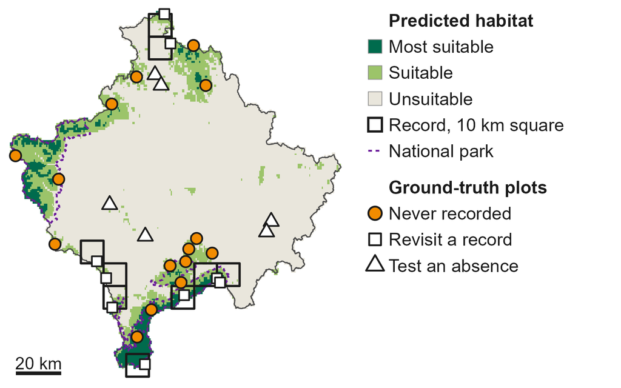

Relative habitat suitability for *Polyommatus eros*, 1 km, an ensemble of small models calibrated outside Kosovo. GBIF 10.15468/dl.265jgv, WorldClim 2.1, CORINE Land Cover 2018.

## Why project data dies on hard drives

**The pattern – in every country, mine included**

1. A project is funded; a consultant or a university team surveys.
2. The deliverable is **a report**. The data is an annex, or a file on a laptop.
3. The project closes. The laptop is replaced.
4. Five years later the same valley is surveyed again, because nobody could find the first survey.

**What it costs**

- **You pay twice**, with public money, for what you already knew.
- **You get no trend.** Two surveys that cannot be compared are not a time series – and trend is what reporting asks for.
- **You cannot defend a decision.** An assessment challenged in court needs the records, not a PDF conclusion.
- **Nobody gets credit**, so nobody hands anything over.

Not a discipline problem – **a missing destination**.

## One central Biodiversity Information System

[output not shown]

## Interoperability: one record, across borders

**Darwin Core** – what a record *is*. The same terms in Pristina, Prague and Skopje, so records merge without a telephone call.

**INSPIRE** – how spatial data is *served*: *Protected sites*, *Species distribution*, *Habitats and biotopes*. The Kosovo Cadastral Agency’s geoportal has run INSPIRE-based services since 2013.

**Across borders** – Sharri and Bjeshkët e Nemuna continue into North Macedonia, Albania and Montenegro, which are building the Bern Convention’s **Emerald Network**. Shared standards let assessments meet at the border.

| Term | Value |
| --- | --- |
| scientificName | *Bombina variegata variegata* |
| eventDate | 2025-06-18T07:04 |
| decimalLatitude | 41.93105 |
| decimalLongitude | 20.69826 |
| coordinateUncertaintyInMeters | 200 |
| basisOfRecord | HumanObservation |
| occurrenceStatus | present |
| license | CC BY-NC 4.0 |

One real Kosovo record in Darwin Core: yellow-bellied toad, Sharri National Park, June 2025 (GBIF occurrence 5897424625). Habitats Directive Annexes II and IV.

## Three systems that work

A Czech database that is open without being reckless. A Ukrainian viewer that turns GBIF into an answer. An English licence that turned newt surveys into faster permits.

## The open-data dilemma

**The fear is legitimate**

Orchids dug up, raptor nests robbed, tortoises taken, cave fauna collected. Precise public localities *have* been misused, in several countries.

Anyone who waves this away has not dealt with it.

**But closing the data protects the wrong people**

- The collector **already knows the site**. The road engineer does not.
- To a planner, a site with no record is **an empty field**.
- Most sites are lost not to a poacher, but to **a bulldozer and a blank map** – lawfully.

The question is not *open or closed*. It is **who sees what, at what precision**.

## NDOP: open by default, precise by permission

- **42 million** published records – the great majority public.
- **Public view:** sensitive species are **generalised**, not hidden – the species visibly occurs in the area; the exact site does not show.
- **Professional view:** full precision for public administration and named users under a **data-use agreement**. Access is logged.
- **Governance, not software:** a named owner of the sensitive list, a review cycle, and species that can come **off** the list.

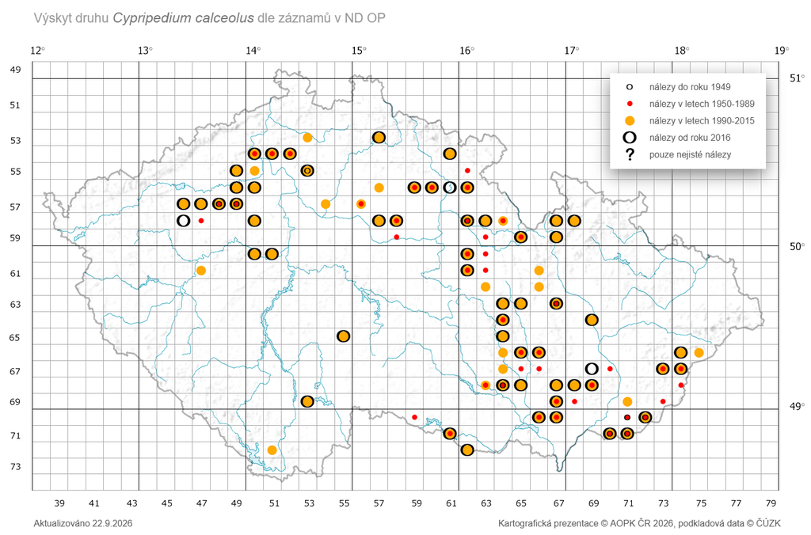

The public view of a sensitive species: present in the square, not pinpointed.

## What the planner sees: the full-precision record

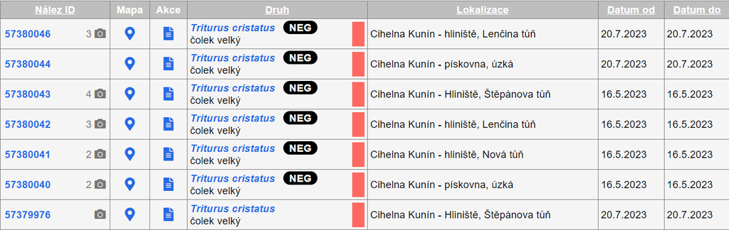

NDOP, logged-in view: great crested newt (*Triturus cristatus*) at one site. Pond-level localities, dates, photographs – and, marked **NEG**, recorded **absences**: ponds surveyed where the newt was *not* found. Absences are what make a trend possible. The same species is the subject of the English case at the end of this section.

## Raw data is not an answer

```
gbifID,scientificName,species,vernacularName,kingdom,phylum,class,order,family,genus,taxonRank,taxonKey
6500474327,"Mantis religiosa (Linne, 1758)",Mantis religiosa,Praying Mantis,Animalia,Arthropoda
6500462703,"Issoria lathonia (Linnaeus, 1758)",Issoria lathonia,Queen of Spain Fritillary,Animalia
6500450749,"Podarcis muralis (Laurenti, 1768)",Podarcis muralis,Common Wall Lizard,Animalia,Chordata
6500428815,Armeria alpina Willd.,Armeria alpina,Alpen-Grasnelke,Plantae,Tracheophyta,Magnoliopsida
6500295185,Gentiana acaulis L.,Gentiana acaulis,Gentiane De Koch,Plantae,Tracheophyta
6500290475,Artemisia vulgaris L.,Artemisia vulgaris,Burot,Plantae,Tracheophyta,Magnoliopsida
… 46,825 more rows, 40 columns
```

**What a developer receives:** the Kosovo GBIF extract. Forty columns, scientific names, no legal meaning.

[figure not shown]

**What a developer needs:** the species in this area, and what the law says about each.

## The UNCG Biodiversity Viewer: GBIF, filtered by law

1. **Area** – district, drawn polygon or KML file, plus a buffer.
2. **Records** – the GBIF occurrences inside it.
3. **Law** – Red Data Book, Bern Convention, EU Habitats and Birds Directive annexes, IUCN, regional lists.
4. **Report** – a table and a DOCX, ready for the EIA file.

Open source (MIT). Built by UNCG and The Habitat Foundation, funded by NLBIF.

[figure not shown]

For Kosovo: replace one table – the national protected-species list – and the code is unchanged.

## Newt surveys on the critical path

**Developers**

Up to a year’s delay, unknowable when the land was bought – and every incentive to argue the newts are not there.

**Newts**

Pond-by-pond mitigation: small, scattered, on the development site, rarely monitored, often failing.

**The regulator**

One application at a time, for ever, with no view of the population it is meant to protect.

## District level licensing: map once, pay once

- Newt presence **modelled across a whole district in advance**, from existing survey data and habitat.
- **Impact risk zones:** RED AMBER GREEN – the developer checks the zone instead of commissioning a seasonal survey.
- A **conservation payment**, set by the impact, replaces bespoke mitigation. The certificate goes in with the planning application.
- The money is pooled: **at least four ponds** created or restored for every occupied pond lost, managed for **25 years**.

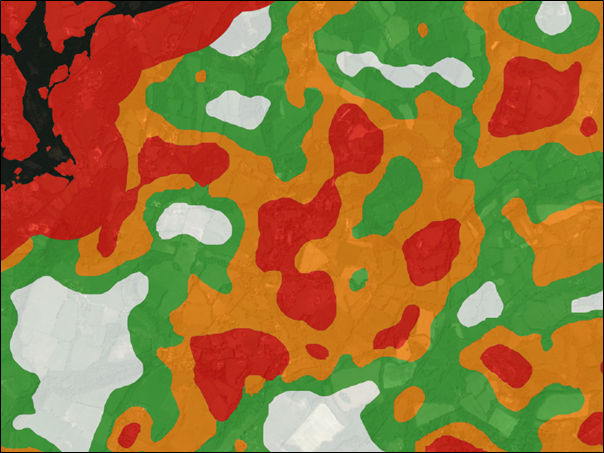

## Next steps: governance that attracts funding

**Govern – first 12 months**

- Name **one owner** for biodiversity data.
- Adopt an **access and sensitive-species policy**.
- Draw boundaries for the **189 point-only sites**.
- Publish **three datasets** to GBIF in Darwin Core.
- Build the **Copernicus change baseline**.

**Build – 1 to 3 years**

- A **pilot** on two sites – Sharri and Ligatina e Hencit – to a draft SDF.
- A central **information system** with tiered access.
- An **area-screening tool** for EIA – the Ukrainian model, Kosovo’s lists.
- **INSPIRE services** for protected sites, through the national geoportal.
- **Repeat monitoring**, with absences recorded.

**Fund**

- Funders back institutions that can show **a baseline, an owner and a data series** – not intentions.
- **IPA III** and the **Green Agenda for the Western Balkans** both prioritise nature.
- A **licensing charge** on the English model is domestic conservation money that grows with development.

Data governance turns Kosovo from a grant applicant into a credible partner.

## Sources

Biodiversity Information Standards (TDWG). n.d. *Darwin Core*. https://dwc.tdwg.org/.

Council of Europe. 1979. *Convention on the Conservation of European Wildlife and Natural Habitats*. https://www.coe.int/en/web/bern-convention/emerald-network.

Council of the European Communities. 1992. *Council Directive 92/43/EEC on the Conservation of Natural Habitats and of Wild Fauna and Flora*. https://eur-lex.europa.eu/eli/dir/1992/43/oj.

European Commission, Directorate-General for Neighbourhood and Enlargement Negotiations. 2026. *TAIEX Expert Mission on Geographic Information Systems (GIS) and Biodiversity Data Management*. Case ID ETT IND/EXP 82606, Pristina, 28–30 September 2026.

European Environment Agency. 2026. *Nationally Designated Areas (NatDA, Formerly CDDA)*. https://doi.org/10.2909/028003e7-7585-4d69-92fc-7f81e0cc2340.

European Environment Agency. n.d. *CORINE Land Cover*. Copernicus Land Monitoring Service. Accessed 22 September 2026. https://land.copernicus.eu/en/products/corine-land-cover.

European Environment Agency, and Swiss Federal Office for the Environment. 2011. *Landscape Fragmentation in Europe*. EEA Report No 2/2011. European Environment Agency. https://www.eea.europa.eu/publications/landscape-fragmentation-in-europe.

European Parliament and Council of the European Union. 2007. *Directive 2007/2/EC Establishing an Infrastructure for Spatial Information in the European Community (INSPIRE)*. https://eur-lex.europa.eu/eli/dir/2007/2/oj.

European Parliament and Council of the European Union. 2021. *Regulation (EU) 2021/1529 Establishing the Instrument for Pre-Accession Assistance (IPA III)*. https://eur-lex.europa.eu/eli/reg/2021/1529/oj.

European Space Agency. n.d. *Sentinel-2 Mission Guide*. https://sentiwiki.copernicus.eu/web/sentinel-2.

European Union, and European Space Agency. n.d. *Copernicus Data Space Ecosystem*. https://dataspace.copernicus.eu/.

Fick, Stephen E., and Robert J. Hijmans. 2017. ‘WorldClim 2: New 1-Km Spatial Resolution Climate Surfaces for Global Land Areas’. *International Journal of Climatology* 37 (12): 4302–15. https://doi.org/10.1002/joc.5086.

Gaigr, Jonáš. 2026. *Biodiversity of Kosovo – GBIF Data Analysis*. Quarto website and reproducible R workflow. https://jonasgaigr.github.io/kosovo-biodiversity-data-workshop-2026/.

Global Biodiversity Information Facility. 2026a. *GBIF Occurrence Download: Kosovo*. https://www.gbif.org/occurrence/download/0003504-260903145123482.

Global Biodiversity Information Facility. 2026b. *GBIF Occurrence Download: *Polyommatus eros*, 18.5–24.5° E, 39.5–44.5° N*. https://doi.org/10.15468/dl.265jgv.

Global Biodiversity Information Facility. n.d. *Integrated Publishing Toolkit (IPT)*. https://www.gbif.org/ipt.

Leaders of the Western Balkans. 2020. *Sofia Declaration on the Green Agenda for the Western Balkans*.

Meha, Murat, Joep Crompvoets, Muzafer Çaka, and Denis Pitarka. 2015. ‘Implementing a National Spatial Data Infrastructure for a Modern Kosovo’. *FIG Working Week 2015*. http://www.fig.net/resources/proceedings/fig_proceedings/fig2015/papers/ts04d/TS04D_meha_crompvoets_et_al_7451.pdf.

Natural England. n.d. *Great Crested Newts: District Level Licensing Schemes for Developers, Ecologists and Landowners*. Accessed 22 September 2026. https://www.gov.uk/government/publications/great-crested-newts-district-level-licensing-schemes-for-developers.

Nature Conservation Agency of the Czech Republic. n.d. *Nálezová Databáze Ochrany Přírody (NDOP) – Species Occurrence Database*. Accessed 22 September 2026. https://portal23.nature.cz/nd/.

NatureSpace Partnership. n.d. *Great Crested Newt District Licensing Scheme: FAQs*. Accessed 22 September 2026. https://naturespaceuk.com/district-licensing/faqs/.

The Habitat Foundation, and Ukrainian Nature Conservation Group. n.d. *Biodiversity Viewer*. Open-source R Shiny application, MIT licence. Accessed 22 September 2026. https://github.com/ABiatov/gbif_shiny_onlineviewer.

United Kingdom. 2017. *The Conservation of Habitats and Species Regulations 2017*. https://www.legislation.gov.uk/uksi/2017/1012/contents.

**THANK YOU FOR YOUR ATTENTION!**

github.com/jonasgaigr/kosovo-biodiversity-data-workshop-2026

[figure not shown]

aopk.gov.cz